# Bayesian two-stage designs for two-arm phase II trials with binary endpoints

Riko Kelter Institute of Medical Statistics and Computational Biology Faculty of Medicine University of Cologne Cologne, Germany

10th April 2026

## 1 Introduction

This vignette illustrates the use of the `optimal_twostage_2arm_bf()` function for designing two-stage two-arm binomial phase II trials based on Bayes factors. We re-analyze a clinical trial discussed in (Kelter 2026) and show how to construct optimal Bayesian two-stage designs in these settings. In contrast to a one-stage design, the designs we aim for in this vignette always include an interim analysis which allows stopping the trial early for futility. Thus, the principal goal of the `optimal_twostage_2arm_bf()` function is to provide a calibrated Bayesian trial design for a phase II trial in terms of power and type-I-error rate (and probability of compelling evidence for the null hypothesis), which enables to stop the trial early for futility in case there is sufficient evidence for the null hypothesis of no effect or an effect too small in magnitude to be considered clinically relevant.

The workflow of finding a calibrated design proceeds as follows. For each trial we:

1. Specify the design and analysis priors under the null hypothesis $H_0$ and the alternative hypothesis $H_1$.
2. Reproduce the fixed-sample (that is, one-stage) operating characteristics using the function `powertwoarmbinbf01()`. This is just for comparing the one-stage sample sizes with the ones of the two-stage design which allows to stop early for futility.
3. Use `optimal_twostage_2arm_bf()` to find an optimal two-stage design with a single interim analysis which allows to stop early for futilty and which minimizes the expected sample size under $H_0$ while maintaining power and controlling the Bayes-factor-based type-I-error.

## 2 Hypotheses and Bayes factors

We consider a two-arm trial with a control arm (arm 1) and a treatment arm (arm 2). Let $p_1$ and $p_2$ denote the response probabilities in the two arms. A typical hypothesis setup is:

- $H_0: p_1 = p_2$,
- $H_1: p_1 \neq p_2$.

The Bayes factor $BF_{01}$ compares the marginal likelihood under $H_0$ to that under $H_1$. Small values of $BF_{01}$ (e.g. $BF_{01} < 1/3$ or $BF_{01} < 1/10$) indicate evidence against $H_0$, whereas large values (e.g. $BF_{01} \ge 3$) indicate evidence in favor of $H_0$. Using the difference parameter $\eta=p_2-p_1$, other typical hypothesis setups for a phase II trial are:

- $H_0:\eta \leq 0 \hspace{1cm} \text{ versus } \hspace{1cm} H_1:\eta > 0$
- $H_0:\eta = 0 \hspace{1cm} \text{ versus } \hspace{1cm} H_1:\eta > 0$
- $H_0:\eta = 0 \hspace{1cm} \text{ versus } \hspace{1cm} H_1:\eta < 0$

For details and further explanations on each of these directional tests, see (Kelter 2026). The associated Bayes factors with each of these three directional tests are denoted as $\mathrm{BF}_{+-}$, $\mathrm{BF}_{+0}$ and $\mathrm{BF}_{-0}$. Also, we denote $H_-:\eta \leq 0$ and $H_+:\eta > 0$.

## 3 Priors: design vs analysis

The package distinguishes **design priors** used for calibrating power and type I error from **analysis priors** used inside the Bayes factor itself.

### 3.1 Design priors

Design priors describe our assumptions about the response probabilities under each hypothesis when computing operating characteristics.

- Under $H_0: p_1 = p_2$: We assume a common response probability $p$ with
  $$p \sim \mathrm{Beta}(a_{0d}, b_{0d}),$$
  set via the parameters `a_0_d` and `b_0_d`.
- Under $H_1: p_1 \neq p_2$: We assume independent priors for the two arms:
  $$p_1 \sim \mathrm{Beta}(a_{1d}, b_{1d}), \quad
  p_2 \sim \mathrm{Beta}(a_{2d}, b_{2d}),$$
  set via the parameters `a_1_d, b_1_d` (for the control group) and `a_2_d, b_2_d` ( for the treatment group).

For directional tests (`test = "BF+0"`, `"BF-0"`, or `"BF+-"`), there are additional design priors under a directional-null $H_-$ (e.g. $p_2 \le p_1$), specified by `a_1_d_Hminus, b_1_d_Hminus, a_2_d_Hminus, b_2_d_Hminus`. These are used for one-sided Bayes factors but can be set to diffuse choices (e.g. Beta(1,1)) for the symmetric `test = "BF01"`. For details on the precise specification of these tests, see (Kelter and Pawel 2025).

### 3.2 Analysis priors

Analysis priors are the priors used *inside* the Bayes factor for each hypothesis. When the hypothesis of interest is tested via the Bayes factor, the analysis priors is the prior used in the calculation of the Bayes factor itself.

- Under $H_0: p_1 = p_2$, the analysis prior for the common response probability again is Beta distributed,
  $$p \sim \mathrm{Beta}(a_{0a}, b_{0a}),$$
  specified by the parameters `a_0_a` and `b_0_a`.
- Under $H_1: p_1 \neq p_2$, we again use independent Betas for the analysis prior:
  $$p_1 \sim \mathrm{Beta}(a_{1a}, b_{1a}), \quad
  p_2 \sim \mathrm{Beta}(a_{2a}, b_{2a}),$$
  specified via the parameters `a_1_a, b_1_a` and `a_2_a, b_2_a`.

Typically, analysis priors are chosen to be relatively diffuse (e.g. Beta(1,1)), while design priors can express more specific beliefs about plausible response rates under each hypothesis. The design priors should express the assumptions or expectations about the effect the novel treatment or drug has, and is influencing the operating characteristics in the planning stage of the trial substantially. Even though the design priors can be highly subjective, it might still be possible to calibrate a design in terms of the resulting power and type-I-error rate. This way, even though the expectations about the effect of the novel drug or treatment might be quite optimistic, the design is legible from a regulatory agency’s point of view, such as the Food and Drug Administration (FDA), see (U.S. Department of Health and Human Services et al. 2020) amd (U.S. Department of Health and Human Services Food and Drug Administration, Center for Drug Evaluation and Research (CDER), Center for Biologics Evaluation and Research (CBER) 2026) or European Medicine Agency (EMA) (European Medicines Agency 2025). In contrast, the analysis prior should be objective in the sense that the actual test carried out at the interim and final analysis is neither in favour of the null nor the alternative hypothesis.

## 4 The function `optimal_twostage_2arm_bf()`

The main design function is `optimal_twostage_2arm_bf()`. For the Bayesian workflow considered in this vignette, the most important arguments are:

- `alpha`: target Bayesian type-I error.
- `beta`: target Bayesian type-II error, so that the target Bayesian power is `1 - beta`.
- `k`: efficacy threshold. Evidence against the null hypothesis is declared if the Bayes factor falls below `k`.
- `k_f`: futility threshold. Compelling evidence for the null hypothesis is declared if the Bayes factor is at least `k_f`.
- `n1_min`: vector of length 2 giving the minimal interim sample sizes in the two arms.
- `n2_max`: vector of length 2 giving the maximal final sample sizes in the two arms.
- `alloc1`, `alloc2`: allocation probabilities to the two arms.
- `power_cushion`: optional extra power margin used in step 1 when identifying a sufficient fixed-sample design.
- `pceH0`: optional lower bound on the probability of compelling evidence in favour of the null hypothesis.
- `interim_fraction`: lower and upper bounds for the interim sample sizes, expressed as fractions of the fixed-sample sizes found in step 1. Defaults to `c(0,1)`, which means all interim designs between `n1_min` and the fixed-sample size found in step 1 of the calibration algorithm are analyzed. If, for example, `interim_fraction = c(0.25,0.75)`, the minimum sample size for the interim analysis starts at 25% of the fixed-sample size found in step 1 of the calibration algorithm, no matter which value `n1_min` takes. Likewise, the maximum sample size for the interim analysis point is 75% of that fixed-sample size.
- `grid_step`: spacing of the interim-design grid searched in step 2.
- `coarse_step`: spacing used in the coarse fixed-sample search in step 1.
- `progress`: logical; if `TRUE`, prints progress messages during the search.
- `max_iter`: maximal number of total sample sizes explored in step 1.
- `calibration_mode`: calibration criterion. In this vignette we use `calibration_mode = "Bayesian"` throughout. Future versions of the package will include other options such as a fully frequentist calibration and a hybrid calibration mode.
- `test`: Bayes-factor test `"BF01"`, `"BF+0"`, `"BF-0"` or `"BF+-"`.

The function returns a list with the following main components:

- `design`: vector `c(n1_1, n1_2, n2_1, n2_2)` giving the interim sample sizes `n1_1` and `n1_2` and the final sample sizes `n2_1` and `n2_2`.
- `naive_oc`: fixed-sample operating characteristics from step 1.
- `occ`: corrected two-stage operating characteristics of the trial design, accounting for possible early stopping for futility.
- `priors`: list containing the prior specification and search settings.
- `conv`: convergence flag describing whether a feasible design was found. Typical values include `"converged"`, `"no_feasible_fixed"`, `"no_interim_grid"`, and `"no_feasible_design"`. Explanations follow below in the example.
- `freq_occ`: optional frequentist operating characteristics. This component is not used in the Bayesian vignette and is therefore not discussed further here. Future versions of the package will include a fully frequentist calibration, too.

In the Bayesian workflow, the corrected operating characteristics in `occ` are the key output, because they quantify the actual two-stage design rather than the fixed-sample surrogate found in step 1 of the calibration algorithm.

## 5 Overview of the calibration algorithm

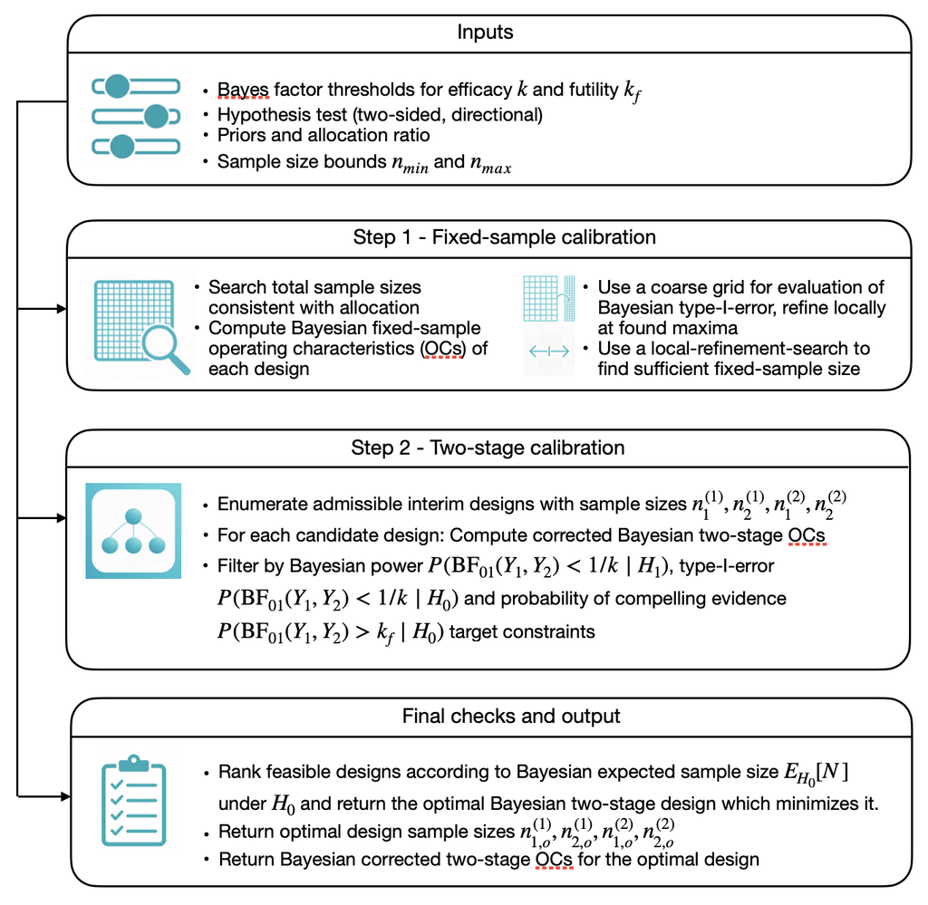

Figure 1: Illustration of the calibration algorithm searching for an optimal Bayesian two-arm two-stage phase II design with binary endpoints

The calibration algorithm in `optimal_twostage_2arm_bf()` proceeds in two steps:

1. **Fixed-sample calibration (step 1)**:  
   It searches over total sample sizes to find a *sufficient* fixed-sample design $(n_2^1, n_2^2)$ that meets the target power $\Pr(\mathrm{BF}_{01}<k\mid H_1)$, type-I error $\Pr(\mathrm{BF}_{01}<k\mid H_0)$ and (optionally) the probability of compelling evidence for the null hypothesis $\Pr(\mathrm{BF}_{01}>k_f\mid H_0)$.
2. **Two-stage calibration (step 2)**:  
   Conditional on this fixed-sample design, it considers all admissible interim sample sizes $(n_1^1, n_1^2)$ on a grid and, for each candidate, computes the corrected operating characteristics. Among those that satisfy the constraints, it selects the design that minimizes the expected sample size under $H_0$.

The **number of interim designs** considered in step 2 is

$$\#\{\text{interim designs}\} = \#\{n_1^1\} \times \#\{n_1^2\},$$

where each arm’s interim range is bounded below by `n1_min` (and `interim_fraction[1] * n_2^j`) and above by `n_2^j - 1` (and `interim_fraction[2] * n_2^j`), and then discretised with `grid_step`. Thus, the **larger** the sufficient fixed-sample size found in step 1, the **larger** the grid of interim designs explored in step 2, and the longer the runtime.

Several modelling choices strongly influence the runtime, and we provide details below after discussing the first example. We turn to the first detailed example now, showing how to calibrate a Bayesian phase II design in practice with the function `optimal_twostage_2arm_bf()`.

## 6 Riociguat phase II trial: fixed-sample design and optimal two-stage design

In this section we consider the **Riociguat phase II trial** in systemic sclerosis (Khanna et al. 2020), re-analysed in (Kelter 2026). We explicitly state the response rates used in the Bayes factor design example.

### 6.1 Riociguat phase II trial: Setup

In the riociguat trial, the reported response rates in the two-arm binary endpoint example are

```r
p1_riociguat <- 38/(22+38) # control arm response probability
p1_riociguat
```

```
#> [1] 0.6333333
```

```r
p2_riociguat <- 48/(48+11)  # treatment arm response probability
p2_riociguat
```

```
#> [1] 0.8135593
```

as given in Section 2.5 of (Kelter 2026). The response in the treatment group is higher compared to the control group, and the test we perform is $H_0:p_1=p_2$ versus $H_+:p_1<p_2$. We thus exclude the possibility that the response probability in the control group can outperform the response probability in the treatment group. If this assumption is too optimistic, we could also perform the test of $H_-:p_2 \le p_1$ versus $H_+:p_1<p_2$ or the two-sided test.

Now, we use the following design and analysis priors for this example:

```r
# flat design priors under H0 and H1 (Riociguat)
a_0_d_rio <- 1
b_0_d_rio <- 1

# slightly informative design prior under H1 (that is, H_+) for the control group
a_1_d_rio <- 1
b_1_d_rio <- 3

# slightly informative design prior under H1 (that is, H_+) for the treatment group
a_2_d_rio <- 3
b_2_d_rio <- 1

# Analysis priors under H0 and H1 (Riociguat)
a_0_a_rio <- 1 # flat under H0
b_0_a_rio <- 1

a_1_a_rio <- 1 # flat under H1 for the control group
b_1_a_rio <- 1

a_2_a_rio <- 1 # flat under H1 for the treatment group
b_2_a_rio <- 1
```

We focus on the one-sided Bayes factor test `test = "BF+0"` with evidence thresholds `k = 1/10` (strong evidence for efficacy) and `k_f = 3` (moderate evidence to stop early for futility), compare (Kelter 2026). We provide a brief discussion of choosing these thresholds below.

### 6.2 Riociguat phase II trial: Finding a one-stage design without an interim analysis

In the one-stage reference design used in (Kelter 2026) for the riociguat example, the trial uses

- $n_1 = 60$ patients in the control arm,
- $n_2 = 59$ patients in the treatment arm,

The design priors are chosen to be slightly informative, as we expect the treatment to be more effective than the placebo in the control group, expressed by the parameters `a_1_d = a_1_d_rio` and so on. The flat analysis priors are set via the parameters `a_1_a = a_1_a_rio` and so on. In the following code, set `progress = TRUE` to obtain all relevant information. It is only turned off in this vignette to avoid cluttered console output.

```r
cat("\n--- Sample size search for riociguat-type trial ---\n")
res_rio_onestage <- ntwoarmbinbf01(
  k = 1/10, k_f = 3,
  power = 0.8, alpha = 0.025, pce_H0 = 0.6,
  test = "BF+0",
  nrange = c(10, 160), n_step = 1,
  progress = TRUE,
  a_0_d = a_0_d_rio, b_0_d = b_0_d_rio,
  a_0_a = a_0_a_rio, b_0_a = b_0_a_rio,
  a_1_d = a_1_d_rio, b_1_d = b_1_d_rio,
  a_2_d = a_2_d_rio, b_2_d = b_2_d_rio,
  a_1_a = a_1_a_rio, b_1_a = b_1_a_rio,
  a_2_a = a_2_a_rio, b_2_a = b_2_a_rio,
  compute_freq_t1e = TRUE,
  p1_power = 0.4, p2_power = 0.6,
  output = "plot"  # Returns recommended n per group
)
```

The output of the function when being called as in the above code looks as follows:

```r
Frequentist power computation: p1=0.40, p2=0.60

Computing for total n = 10 to 160 (step = 1, 151 values)

Allocation: alloc1 = 0.500, alloc2 = 0.500


Frequentist Type-I error computation: ENABLED

Frequentist power computation: ENABLED



Simulation complete.


SUMMARY for BF+0:

  Hypotheses: BF+0 test: H0: p1 = p2 vs H+: p2 > p1

  k = 0.100, k_f = 3.000

  Allocation: alloc1 = 0.500, alloc2 = 0.500

  Target power = 0.800, alpha = 0.025, P(CE|H0) = 0.600


    Power >= 0.800 achieved at n_total=51

    Bayesian Type-I error <= 0.025 achieved at n_total=10

    P(CE|H0) >= 0.600 achieved at n_total=43

    Frequentist Type-I error <= 0.025 achieved (max(sup)=0.021)

    Frequentist power not reached: max=0.509 at n_total=160 (p1=0.400, p2=0.600)
```

We can access the resulting one-stage fixed-sample design via

```r
res_rio_onestage
```

if required. A more practical way is to plot the resulting design and the function always produces a plot when being called with the argument `output ="plot"`.

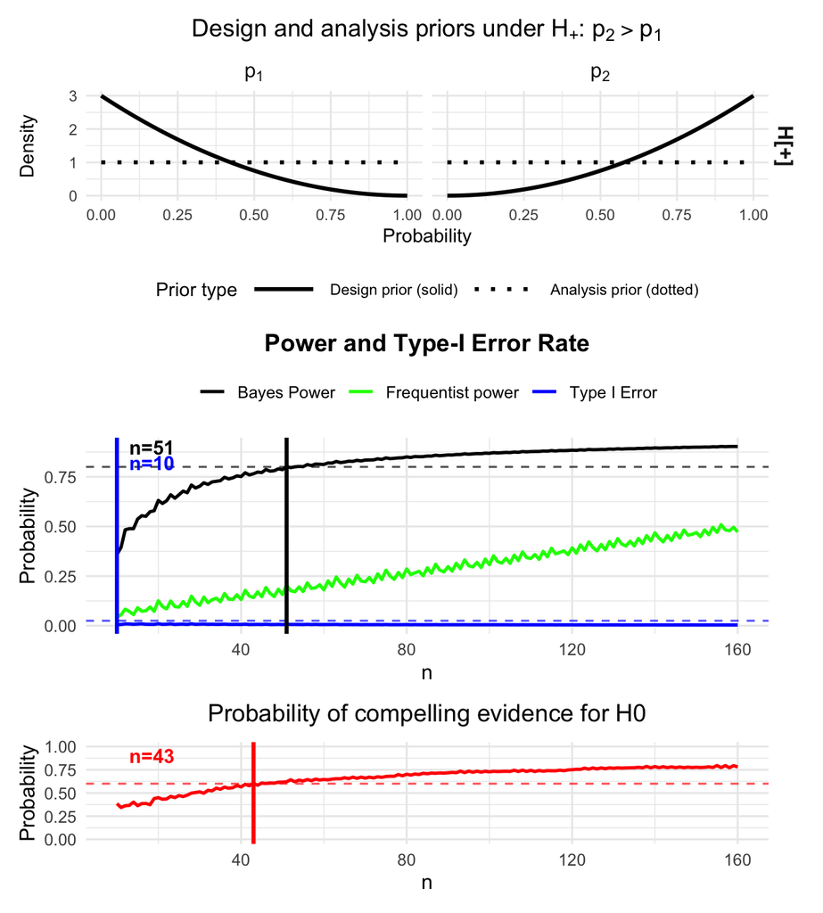

Figure 2: The calibrated Bayesian two-arm one-stage phase II design with binary endpoints. No interim analysis is carried out and the design is calibrated according to the target constraints of 80% Bayesian power, 2.5% Bayesian type-I-error and 60% probability of compelling evidence for the null hypothesis.

The plot shows the results of the calibrated one-stage design developed by (Kelter 2026), and illustrates that the one-stage design without an interim analysis requires $51$ patients in total (check `res_rio_onestage`) to reach the desired threshold for Bayesian power, while $43$ patients in total are necessary to also reach the desired probability of compelling evidence for the null hypothesis. The (Bayesian) type-I-error rate is calibrated for even $10$ patients in total (5 per trial arm). The frequentist type-I-error rate is achieved with a supremum at `0.021` (see console output when running the above code), while the frequentist power requirement of 80% is not reached (maximum of `0.509` reached at 160 patients, see console output). Now, this one-stage design does **not** include an interim analysis, but is fully calibrated from a Bayesian point of view. We could also modify the parameters `p1_power` and `p2_power` to provide frequentist power calculations under more optimistic assumptions (here, we assumed about 20% less successes in both the treatment and control than the response rates actually observed in the trial, so setting `p1_power = 0.6` and `p2_power = 0.8` might be more realistic and yield a design which also is calibrated in terms of frequentist power then). However, we turn to finding the optimal **two-stage** design in the next step now, which includes an interim analysis to stop early for futility. We only computed this fixed-sample one-stage design to compare it with the two-stage design computed next.